# Project: Investigate a Dataset - [TMDB-movies]

- Introduction
- Data Wrangling
- Exploratory Data Analysis
- Conclusions

## Introduction

### Dataset Description

> This data set contains information about 10,000 movies collected from The Movie Database (TMDb), including user ratings and revenue.

> columns:

> id

> imdb_id

> popularity

> budget

> revenue

> original_title

> cast

> homepage

> director

> tagline

> keywords

> overview

> runtime

> genres

> production_companies

> release_date

> vote_count

> vote_average

> release_year

> budget_adj

> revenue_adj

### Question(s) for Analysis

> **Q1**: Which genres are most popular from year to year?

> **Q2**: Who is the most frequent actor?

> **Q3**: Which Production Companies has Higher Number Of Release?

> **Q4**: Which Keywords most frequent in movies?

> **Q5**: who is the most frequent director?

> **Q6**: What kinds of properties are associated with movies that have high revenues?

```python
import matplotlib.pyplot as plt
import pandas as pd
import seaborn as sns
%matplotlib inline
df = pd.read_csv('Database/tmdb-movies.csv')
df.head()
```

|  | id | imdb_id | popularity | budget | revenue | original_title | cast | homepage | director | tagline | ... | overview | runtime | genres | production_companies | release_date | vote_count | vote_average | release_year | budget_adj | revenue_adj |
| --- | --- | --- | --- | --- | --- | --- | --- | --- | --- | --- | --- | --- | --- | --- | --- | --- | --- | --- | --- | --- | --- |
| 0 | 135397 | tt0369610 | 32.985763 | 150000000 | 1513528810 | Jurassic World | Chris Pratt\|Bryce Dallas Howard\|Irrfan Khan\|Vi... | http://www.jurassicworld.com/ | Colin Trevorrow | The park is open. | ... | Twenty-two years after the events of Jurassic ... | 124 | Action\|Adventure\|Science Fiction\|Thriller | Universal Studios\|Amblin Entertainment\|Legenda... | 6/9/15 | 5562 | 6.5 | 2015 | 1.379999e+08 | 1.392446e+09 |
| 1 | 76341 | tt1392190 | 28.419936 | 150000000 | 378436354 | Mad Max: Fury Road | Tom Hardy\|Charlize Theron\|Hugh Keays-Byrne\|Nic... | http://www.madmaxmovie.com/ | George Miller | What a Lovely Day. | ... | An apocalyptic story set in the furthest reach... | 120 | Action\|Adventure\|Science Fiction\|Thriller | Village Roadshow Pictures\|Kennedy Miller Produ... | 5/13/15 | 6185 | 7.1 | 2015 | 1.379999e+08 | 3.481613e+08 |
| 2 | 262500 | tt2908446 | 13.112507 | 110000000 | 295238201 | Insurgent | Shailene Woodley\|Theo James\|Kate Winslet\|Ansel... | http://www.thedivergentseries.movie/#insurgent | Robert Schwentke | One Choice Can Destroy You | ... | Beatrice Prior must confront her inner demons ... | 119 | Adventure\|Science Fiction\|Thriller | Summit Entertainment\|Mandeville Films\|Red Wago... | 3/18/15 | 2480 | 6.3 | 2015 | 1.012000e+08 | 2.716190e+08 |
| 3 | 140607 | tt2488496 | 11.173104 | 200000000 | 2068178225 | Star Wars: The Force Awakens | Harrison Ford\|Mark Hamill\|Carrie Fisher\|Adam D... | http://www.starwars.com/films/star-wars-episod... | J.J. Abrams | Every generation has a story. | ... | Thirty years after defeating the Galactic Empi... | 136 | Action\|Adventure\|Science Fiction\|Fantasy | Lucasfilm\|Truenorth Productions\|Bad Robot | 12/15/15 | 5292 | 7.5 | 2015 | 1.839999e+08 | 1.902723e+09 |
| 4 | 168259 | tt2820852 | 9.335014 | 190000000 | 1506249360 | Furious 7 | Vin Diesel\|Paul Walker\|Jason Statham\|Michelle ... | http://www.furious7.com/ | James Wan | Vengeance Hits Home | ... | Deckard Shaw seeks revenge against Dominic Tor... | 137 | Action\|Crime\|Thriller | Universal Pictures\|Original Film\|Media Rights ... | 4/1/15 | 2947 | 7.3 | 2015 | 1.747999e+08 | 1.385749e+09 |

5 rows × 21 columns

## Data Wrangling

### General Properties

```python
df.shape
```

```
(10866, 21)
```

```python
df.describe()
```

|  | id | popularity | budget | revenue | runtime | vote_count | vote_average | release_year | budget_adj | revenue_adj |
| --- | --- | --- | --- | --- | --- | --- | --- | --- | --- | --- |
| count | 10866.000000 | 10866.000000 | 1.086600e+04 | 1.086600e+04 | 10866.000000 | 10866.000000 | 10866.000000 | 10866.000000 | 1.086600e+04 | 1.086600e+04 |
| mean | 66064.177434 | 0.646441 | 1.462570e+07 | 3.982332e+07 | 102.070863 | 217.389748 | 5.974922 | 2001.322658 | 1.755104e+07 | 5.136436e+07 |
| std | 92130.136561 | 1.000185 | 3.091321e+07 | 1.170035e+08 | 31.381405 | 575.619058 | 0.935142 | 12.812941 | 3.430616e+07 | 1.446325e+08 |
| min | 5.000000 | 0.000065 | 0.000000e+00 | 0.000000e+00 | 0.000000 | 10.000000 | 1.500000 | 1960.000000 | 0.000000e+00 | 0.000000e+00 |
| 25% | 10596.250000 | 0.207583 | 0.000000e+00 | 0.000000e+00 | 90.000000 | 17.000000 | 5.400000 | 1995.000000 | 0.000000e+00 | 0.000000e+00 |
| 50% | 20669.000000 | 0.383856 | 0.000000e+00 | 0.000000e+00 | 99.000000 | 38.000000 | 6.000000 | 2006.000000 | 0.000000e+00 | 0.000000e+00 |
| 75% | 75610.000000 | 0.713817 | 1.500000e+07 | 2.400000e+07 | 111.000000 | 145.750000 | 6.600000 | 2011.000000 | 2.085325e+07 | 3.369710e+07 |
| max | 417859.000000 | 32.985763 | 4.250000e+08 | 2.781506e+09 | 900.000000 | 9767.000000 | 9.200000 | 2015.000000 | 4.250000e+08 | 2.827124e+09 |

```python
df.info()
```

```
<class 'pandas.core.frame.DataFrame'>
RangeIndex: 10866 entries, 0 to 10865
Data columns (total 21 columns):
 #   Column                Non-Null Count  Dtype
---  ------                --------------  -----
 0   id                    10866 non-null  int64
 1   imdb_id               10856 non-null  object
 2   popularity            10866 non-null  float64
 3   budget                10866 non-null  int64
 4   revenue               10866 non-null  int64
 5   original_title        10866 non-null  object
 6   cast                  10790 non-null  object
 7   homepage              2936 non-null   object
 8   director              10822 non-null  object
 9   tagline               8042 non-null   object
 10  keywords              9373 non-null   object
 11  overview              10862 non-null  object
 12  runtime               10866 non-null  int64
 13  genres                10843 non-null  object
 14  production_companies  9836 non-null   object
 15  release_date          10866 non-null  object
 16  vote_count            10866 non-null  int64
 17  vote_average          10866 non-null  float64
 18  release_year          10866 non-null  int64
 19  budget_adj            10866 non-null  float64
 20  revenue_adj           10866 non-null  float64
dtypes: float64(4), int64(6), object(11)
memory usage: 1.7+ MB
```

### Data Cleaning

```python
df.drop(['budget', 'revenue', 'overview', 'homepage', 'tagline'], axis=1, inplace=True)
df.head()
```

|  | id | imdb_id | popularity | original_title | cast | director | keywords | runtime | genres | production_companies | release_date | vote_count | vote_average | release_year | budget_adj | revenue_adj |
| --- | --- | --- | --- | --- | --- | --- | --- | --- | --- | --- | --- | --- | --- | --- | --- | --- |
| 0 | 135397 | tt0369610 | 32.985763 | Jurassic World | Chris Pratt\|Bryce Dallas Howard\|Irrfan Khan\|Vi... | Colin Trevorrow | monster\|dna\|tyrannosaurus rex\|velociraptor\|island | 124 | Action\|Adventure\|Science Fiction\|Thriller | Universal Studios\|Amblin Entertainment\|Legenda... | 6/9/15 | 5562 | 6.5 | 2015 | 1.379999e+08 | 1.392446e+09 |
| 1 | 76341 | tt1392190 | 28.419936 | Mad Max: Fury Road | Tom Hardy\|Charlize Theron\|Hugh Keays-Byrne\|Nic... | George Miller | future\|chase\|post-apocalyptic\|dystopia\|australia | 120 | Action\|Adventure\|Science Fiction\|Thriller | Village Roadshow Pictures\|Kennedy Miller Produ... | 5/13/15 | 6185 | 7.1 | 2015 | 1.379999e+08 | 3.481613e+08 |
| 2 | 262500 | tt2908446 | 13.112507 | Insurgent | Shailene Woodley\|Theo James\|Kate Winslet\|Ansel... | Robert Schwentke | based on novel\|revolution\|dystopia\|sequel\|dyst... | 119 | Adventure\|Science Fiction\|Thriller | Summit Entertainment\|Mandeville Films\|Red Wago... | 3/18/15 | 2480 | 6.3 | 2015 | 1.012000e+08 | 2.716190e+08 |
| 3 | 140607 | tt2488496 | 11.173104 | Star Wars: The Force Awakens | Harrison Ford\|Mark Hamill\|Carrie Fisher\|Adam D... | J.J. Abrams | android\|spaceship\|jedi\|space opera\|3d | 136 | Action\|Adventure\|Science Fiction\|Fantasy | Lucasfilm\|Truenorth Productions\|Bad Robot | 12/15/15 | 5292 | 7.5 | 2015 | 1.839999e+08 | 1.902723e+09 |
| 4 | 168259 | tt2820852 | 9.335014 | Furious 7 | Vin Diesel\|Paul Walker\|Jason Statham\|Michelle ... | James Wan | car race\|speed\|revenge\|suspense\|car | 137 | Action\|Crime\|Thriller | Universal Pictures\|Original Film\|Media Rights ... | 4/1/15 | 2947 | 7.3 | 2015 | 1.747999e+08 | 1.385749e+09 |

i dropped `overview` and `homepage` because i don't need it, and `tagline` has a lot of Nan values.

```python
# getting the top nan-value counts
df.isnull().sum().sort_values(ascending=False)
```

```
keywords                1493
production_companies    1030
cast                      76
director                  44
genres                    23
imdb_id                   10
id                         0
popularity                 0
original_title             0
runtime                    0
release_date               0
vote_count                 0
vote_average               0
release_year               0
budget_adj                 0
revenue_adj                0
dtype: int64
```

there's a lot not null values in `keywords` and `production_companies` but i will keep them because i will use them in my analysis.

```python
df.duplicated().sum()
```

```
1
```

```python
df.drop_duplicates(inplace=True)
```

let's make the columns `genres`, `casts`, `production_companies` and `keywords` as lists instead of a long string.

```python
to_split = ['genres', 'cast', 'production_companies', 'keywords']
for col in to_split:
    df[col] = df[col].str.split('|')

df[to_split].head()
```

|  | genres | cast | production_companies | keywords |
| --- | --- | --- | --- | --- |
| 0 | [Action, Adventure, Science Fiction, Thriller] | [Chris Pratt, Bryce Dallas Howard, Irrfan Khan... | [Universal Studios, Amblin Entertainment, Lege... | [monster, dna, tyrannosaurus rex, velociraptor... |
| 1 | [Action, Adventure, Science Fiction, Thriller] | [Tom Hardy, Charlize Theron, Hugh Keays-Byrne,... | [Village Roadshow Pictures, Kennedy Miller Pro... | [future, chase, post-apocalyptic, dystopia, au... |
| 2 | [Adventure, Science Fiction, Thriller] | [Shailene Woodley, Theo James, Kate Winslet, A... | [Summit Entertainment, Mandeville Films, Red W... | [based on novel, revolution, dystopia, sequel,... |
| 3 | [Action, Adventure, Science Fiction, Fantasy] | [Harrison Ford, Mark Hamill, Carrie Fisher, Ad... | [Lucasfilm, Truenorth Productions, Bad Robot] | [android, spaceship, jedi, space opera, 3d] |
| 4 | [Action, Crime, Thriller] | [Vin Diesel, Paul Walker, Jason Statham, Miche... | [Universal Pictures, Original Film, Media Righ... | [car race, speed, revenge, suspense, car] |

#### extracting all genres

```python
df.genres.head()
```

```
0    [Action, Adventure, Science Fiction, Thriller]
1    [Action, Adventure, Science Fiction, Thriller]
2            [Adventure, Science Fiction, Thriller]
3     [Action, Adventure, Science Fiction, Fantasy]
4                         [Action, Crime, Thriller]
Name: genres, dtype: object
```

```python
def extract_unique_values(column):
    """Extract a set of unique values from a column that contains lists of values in each row.

    Args:
        column (pandas.Series): the Columns to extract the values from.

    Returns:
        Set: The set of unique values.
    """
    column = column.dropna()
    result = set()
    for v in column:
        result = result.union(v)

    return result
```

```python
all_genres = extract_unique_values(df.genres)
all_genres
```

```
{'Action',
 'Adventure',
 'Animation',
 'Comedy',
 'Crime',
 'Documentary',
 'Drama',
 'Family',
 'Fantasy',
 'Foreign',
 'History',
 'Horror',
 'Music',
 'Mystery',
 'Romance',
 'Science Fiction',
 'TV Movie',
 'Thriller',
 'War',
 'Western'}
```

```python
len(all_genres)
```

```
20
```

## Exploratory Data Analysis

### Research Question 1: Which genres are most popular from year to year?

first let's see which is the most popular genre in this database

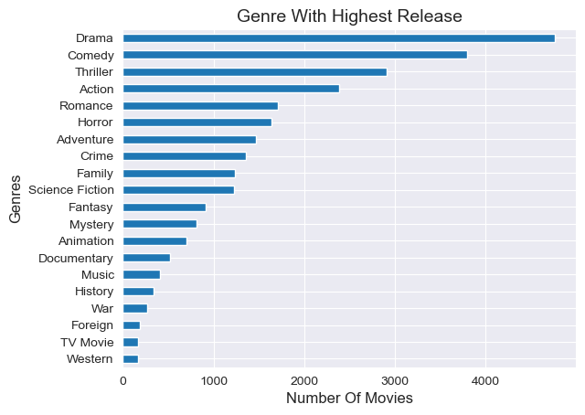

```python
# expanding the genres columns and counting the values.
genres_counts = df.genres.explode().value_counts(ascending=True)
genres_counts.plot(kind='barh')

plt.title("Genre With Highest Release", fontsize=14)
plt.xlabel('Number Of Movies', fontsize=12)
plt.ylabel("Genres", fontsize=12)
```

Drama is the genre with highest releases followed by Comedy, Thriller and Action.

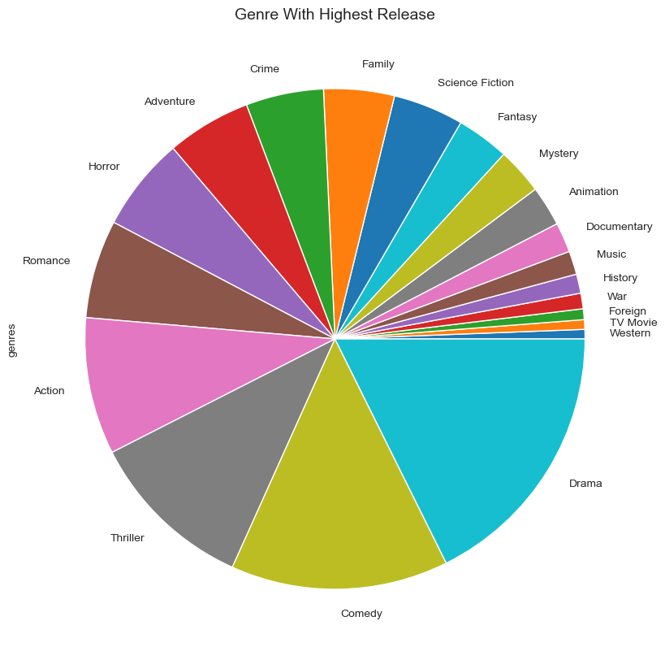

```python
genres_counts.plot(kind='pie', figsize=(10, 10))
plt.title("Genre With Highest Release", fontsize=14)
```

it's seems that Drama, Comedy, Thriller and Action makes of half the number of releases

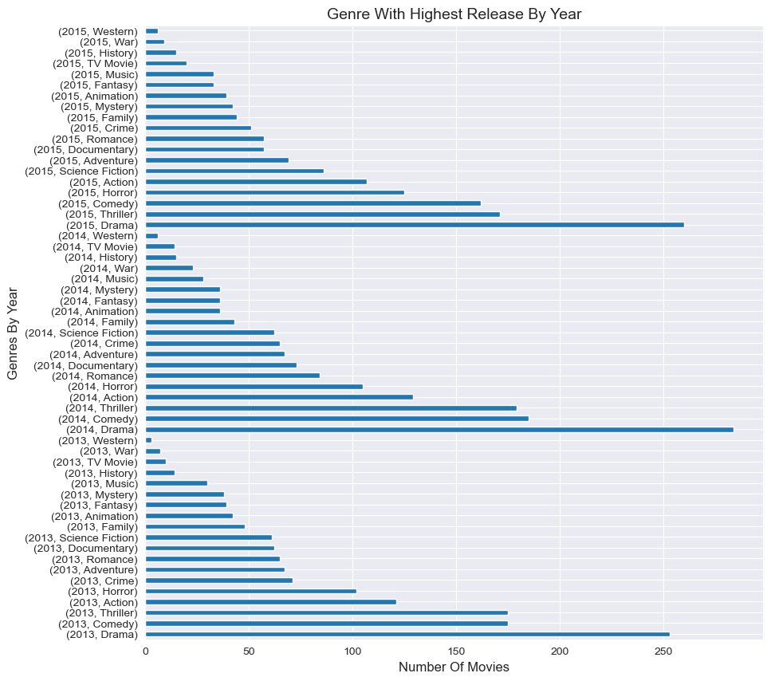

```python
# let's get the highest release by year for 2013 up to 2015.
genres_by_year = df[['release_year', 'genres']].explode(column='genres').groupby('release_year', ).value_counts()
genres_by_year.loc[2013:].plot(kind='barh', figsize=(10, 10))

plt.title("Genre With Highest Release By Year", fontsize=14)
plt.xlabel('Number Of Movies', fontsize=12)
plt.ylabel("Genres By Year", fontsize=12)
```

from 2013 to 2015, Drama is the genre with highest number of movies.

### Research Question 2: Who is the most frequent actor?

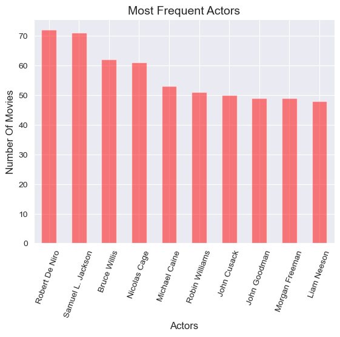

```python
top_10_actors_counts = df.cast.explode().value_counts()[:10]

# plotting the count result
top_10_actors_counts.plot(kind='bar', color='red', alpha=.5)
plt.title("Most Frequent Actors", fontsize=14)
plt.xlabel('Actors', fontsize=12)
plt.xticks(rotation=70)
plt.ylabel('Number Of Movies', fontsize=12)
```

Robert De Nitro and Samuel L. Jackson are most frequent actors.

### Research Question 3: Which Production Companies has Higher Number Of Release?

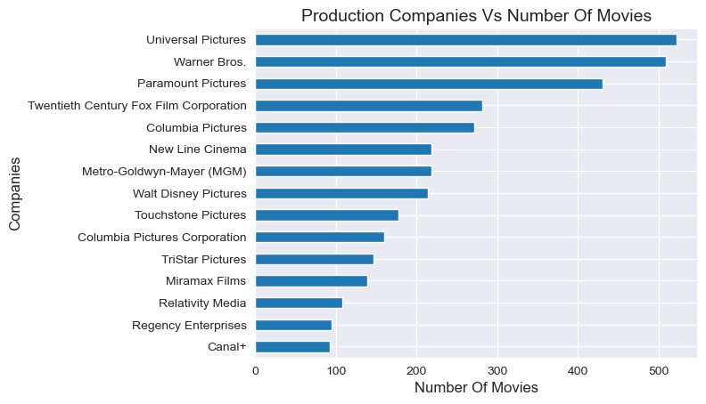

```python
top_15_production_companies = df.production_companies.explode().value_counts()[:15]

# plotting production companies Vs number Of movies from the highest number of movies to the lowest.
top_15_production_companies[::-1].plot(kind='barh')
plt.title("Production Companies Vs Number Of Movies", fontsize=14)
plt.xlabel('Number Of Movies', fontsize=12)
plt.ylabel("Companies", fontsize=12)
```

Universal Pictures is the company that produces highest number of the movies, followed by Warner Bros.

### Research Question 4: Which Keywords most frequent in movies?

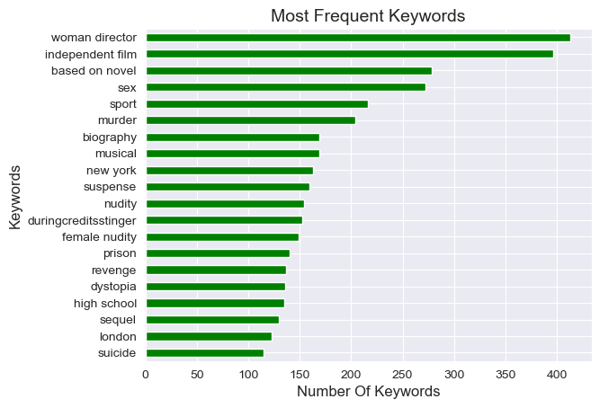

```python
top_20_keywords = df.keywords.explode().value_counts()[:20]

# plotting the most frequent keywords from the highest to the lowest.
top_20_keywords[::-1].plot(kind='barh', color='green')
plt.title("Most Frequent Keywords", fontsize=14)
plt.xlabel('Number Of Keywords', fontsize=12)
plt.ylabel("Keywords", fontsize=12)
```

woman director, independent film and based on novel are the most frequent keywords in the database.

### Research Question 5: who is the most frequent director?

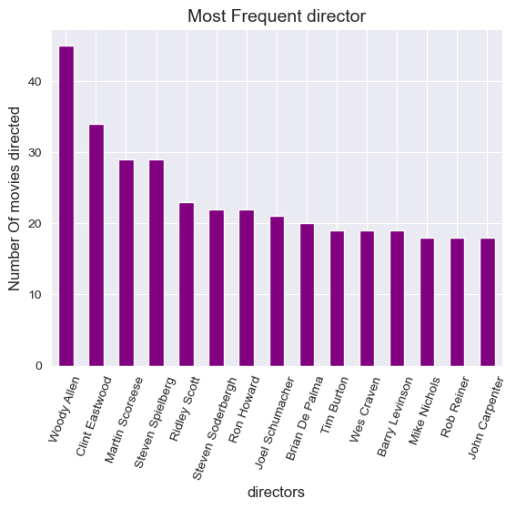

```python
top_15_directors = df.director.explode().value_counts()[:15]

# plotting most frequent director of movies.
top_15_directors.plot(kind='bar', color='purple')
plt.title("Most Frequent director", fontsize=14)
plt.xlabel("directors", fontsize=12)
plt.xticks(rotation=70)
plt.ylabel('Number Of movies directed', fontsize=12)
```

Woody Allen, Clint Eastwood and Martin Scorsese are the most frequent directors.

### Research Question 6: What kinds of properties are associated with movies that have high revenues?

let's find the movies with the highest revenues

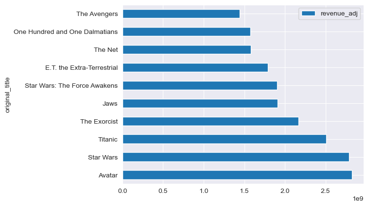

```python
top_10 = df.sort_values('revenue_adj', ascending=False)[['original_title', 'revenue_adj']].head(10)
top_10.plot(kind='barh', x='original_title')
```

ok, so Avatar the first, and Star Wars is the second by a little difference.

now, let's see if high budget leads to high revenue:

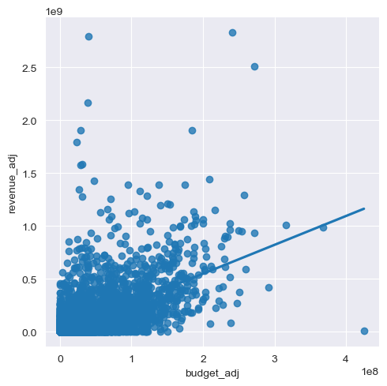

```python
sns.lmplot(data=df, x='budget_adj', y='revenue_adj', ci=None)
```

there is a tendency for a movies to be more profitable if it has more budget.

what about voting average?

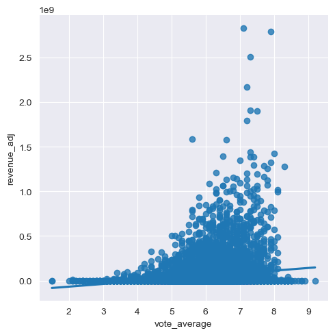

```python
sns.lmplot(data=df, x='vote_average', y='revenue_adj', ci=None)
```

it seems that the relationship between `vote_average` and `revenue_adj` is a not linear one.

let's check the popularity

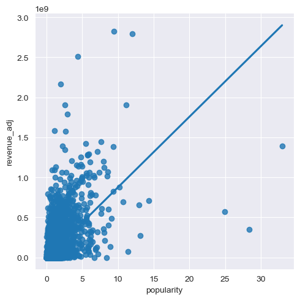

```python
sns.lmplot(data=df, x='popularity', y='revenue_adj', ci=None)
```

a non linear relationship again.

which genre generate more revenue

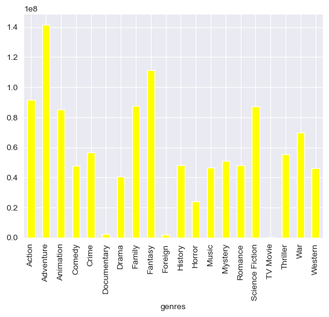

```python
# extracting average revenue par genre
reveue_par_genre = df.explode('genres') \
    .groupby('genres') \
    .revenue_adj.mean()


reveue_par_genre.plot(kind='bar', color='yellow')
```

Adventure is the highest revenue generating genre.

## Conclusions

> Drama is the genre that has most number of movies, following by comedy, thriller and action.

> 'Avatar', 'Star Wars' and 'Titanic' are the most profitable movies.

> Universal Pictures, Warner Bros and Paramount Pictures production companies made more movies than the other companies.

### limitations

> a lot of relations between variables are non-linear so didn't conclude too much from the data.

> there is a positive correlation between budgets and revenues, but we didn't specify and quantify it.